# Лабораторная работа № 3

## Конфигурация Kea DDNS

Заданы параметры обновления прямой и обратной зон через DNS-сервер `192.168.1.1`.

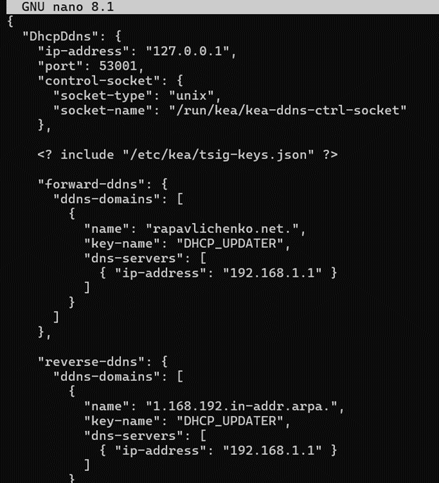

## Запуск службы DDNS

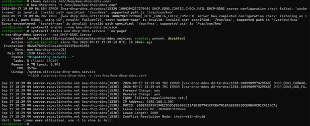

## Включение DDNS в DHCP

В `kea-dhcp4.conf` включены обновления и указан домен `rapavlichenko.net`.

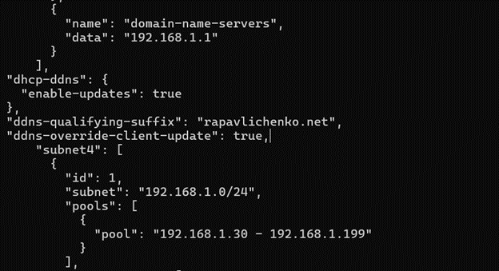

## Перезапуск DHCP-сервера

Журнал подтвердил успешную работу Kea после включения динамических обновлений.

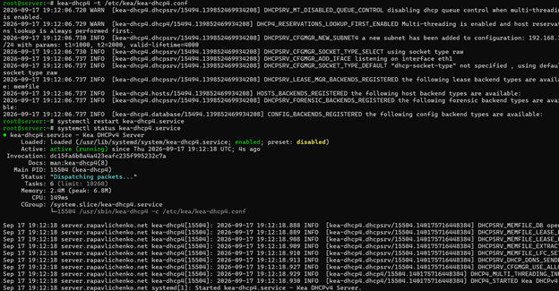

# Результаты

## Повторное получение адреса

Клиентское соединение `eth1` переподключено для обновления аренды и DNS-записи.

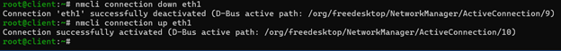

## Журнал динамической зоны

Появление файла `.jnl` подтвердило принятие динамического обновления сервером BIND.

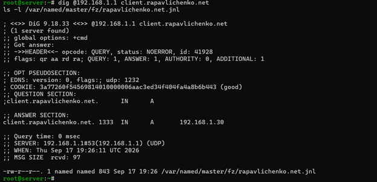

## Проверка DNS-записи клиента

Команда `dig` вернула A-запись `client.rapavlichenko.net` с адресом `192.168.1.30`.

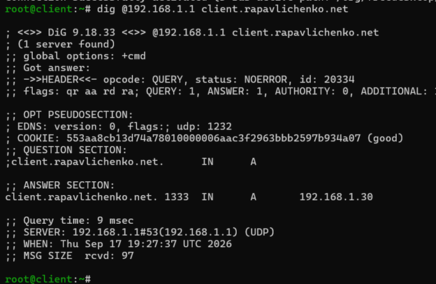

# Автоматизация

## Сохранение конфигурации DHCP

Рабочие файлы Kea скопированы в каталог `provision/server/dhcp`.

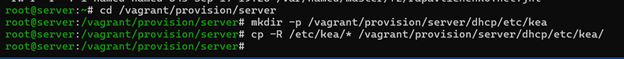

## Обновление конфигурации DNS

Фактические файлы BIND скопированы в каталог автоматического развёртывания.

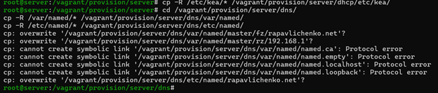

## Создание сценария dhcp.sh

В каталоге `provision/server` создан исполняемый сценарий настройки DHCP.

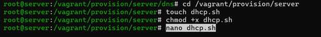

## Содержимое сценария

Сценарий устанавливает Kea, копирует конфигурацию, настраивает права, SELinux и `firewalld`, затем запускает службы DHCP и DDNS.

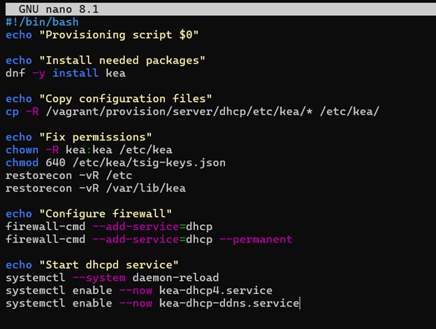

## Подключение сценария к серверу

Provisioner `server dhcp` запускает сценарий после настройки DNS.

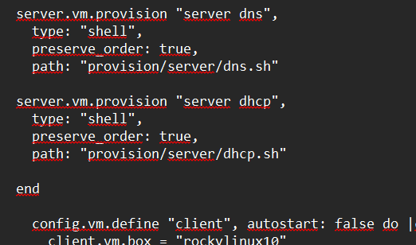

## Завершение работы

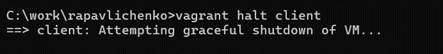

# Контрольные вопросы

## DHCP и сетевые подключения

- NetworkManager хранит профили в `/etc/NetworkManager/system-connections/`.
- DHCP автоматически выдаёт IP-адрес, маску, шлюз, DNS-серверы и срок аренды.
- Основной обмен выполняется сообщениями DHCPDISCOVER, DHCPOFFER, DHCPREQUEST и DHCPACK.
- Сервер использует UDP-порт 67, клиент — порт 68.

## Файлы Kea и DDNS

- `/etc/kea/kea-dhcp4.conf` содержит настройки DHCPv4.
- `/etc/kea/kea-dhcp-ddns.conf` задаёт взаимодействие с DNS.
- `/var/lib/kea/kea-leases4.csv` хранит сведения об арендах.
- DDNS автоматически создаёт и обновляет A- и PTR-записи.
- TSIG-ключ защищает запросы динамического обновления.

## Диагностические утилиты

- `ifconfig` показывает адреса, состояние и статистику интерфейсов.
- `ifconfig -a` выводит также отключённые интерфейсы.
- `ping -c 4 192.168.1.1` проверяет доступность четырьмя запросами.
- Итоговая статистика `ping` показывает задержку и потери пакетов.

# Выводы

## Выводы

В ходе работы были получены практические навыки установки и конфигурирования DHCP-сервера Kea. Сервер автоматически выдал клиенту сетевые параметры, а настройка DDNS обеспечила создание записи `client.rapavlichenko.net`. Сценарии Vagrant сохранили выполненную конфигурацию для повторного развёртывания стенда.